# Univariate plotting & summary metrics of spatial model output

Ben Williams

October 26, 2015

The *vplot* function will generate a figure for each year and area. Input a dataframe containing the species of interest, subsets of the “All_sp_index_meanCPUEByArea.csv”" file. The location of this may change when the model is updated.

A seperate file can be used to house a data.frame of species names and trophic guilds etc. This file can be used to inform vplot of the groups to plot (example code below). Further this will allow for relatively painless exmainations of guild variance vs the whole, etc.

Map of area locations

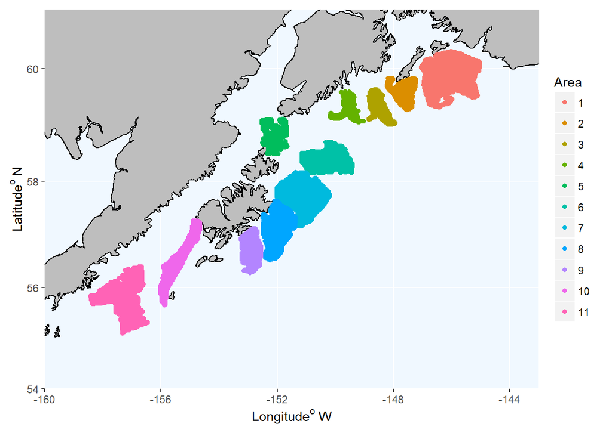

Function for generating figures

```r
vplot <- function(x, title=""){
  require(ggplot2)
  theme_set(theme_bw(base_size=12,base_family='Times New Roman')+
  theme(panel.grid.major = element_blank(),
  panel.grid.minor = element_blank()))
a <- aggregate(vari~area+year,data=x,FUN=sum)
b <- aggregate(Mean.totalDensity~area+year,data=x,FUN=sum)
c <- merge(a, b, by=c("area", "year"))
c$se <- sqrt(c$vari)
c$uci <- c$se*2 + c$Mean.totalDensity
c$lci <- c$Mean.totalDensity - c$se*2
c$Area <- factor(c$area)

year.range <- c(1984,1987,1990,1993,1996,seq(1999,2015,by=2))
ggplot(c, aes(year, Mean.totalDensity, group=Area, color=Area))+geom_line()+
  geom_ribbon(aes(ymin=lci, ymax=uci, fill=Area), alpha=.2, linetype=0)+
  ylim(min(c$lci), max(c$uci))+ scale_x_continuous(limits=c(1984, 2015), breaks=year.range)+ggtitle(title)+xlab("Year")+ylab("Mean total density") +
  theme(text=element_text(family="Helvetica"),axis.text.x = element_text(angle = 90,hjust=1,vjust=0.5))
}
```

Subset groups based upon “trawl_species_control_file.csv”

```r
sp <- subset(trawl_species, pelagic.benthic!='pelagic')
sp <- droplevels(sp)
sp.names <- as.list(levels(sp$database.name))
```

Define the group to plot based upon the species names pulled from the database

```r
group <- meanCPUE[meanCPUE$Species %in% sp.names,]
```

Plot the group

[output not shown]

[output not shown]

[output cut: 25 more lines]

[output not shown]

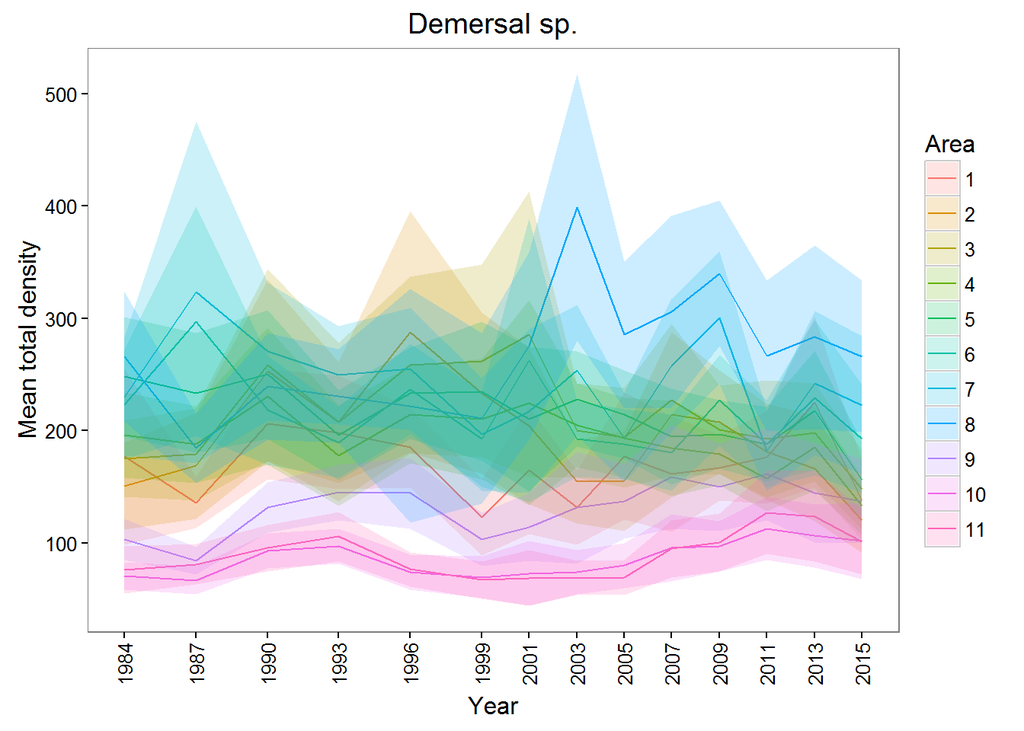

```r
vplot(group,title="Demersal sp.")
```

Examine by guild

[output not shown]

[output not shown]

[output cut: 25 more lines]

[output not shown]

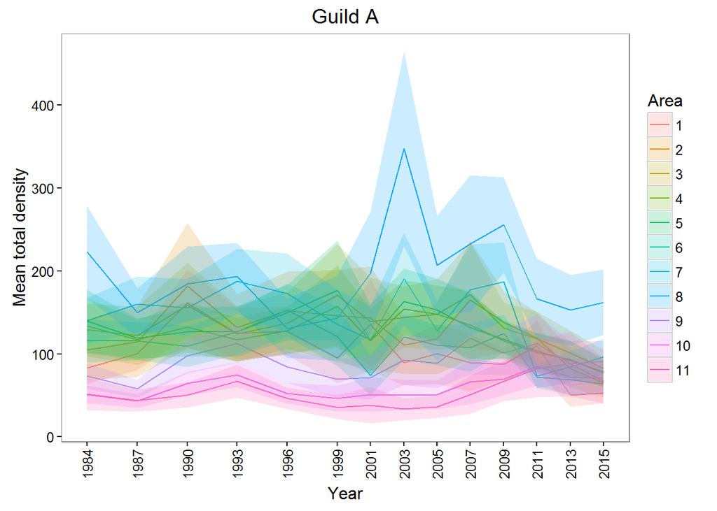

```r
sp <- subset(trawl_species, guild=='A')
sp <- droplevels(sp)
sp.names <- as.list(levels(sp$database.name))

group <- meanCPUE[meanCPUE$Species %in% sp.names,]

vplot(group, title="Guild A")
```

[output not shown]

[output not shown]

[output cut: 25 more lines]

[output not shown]

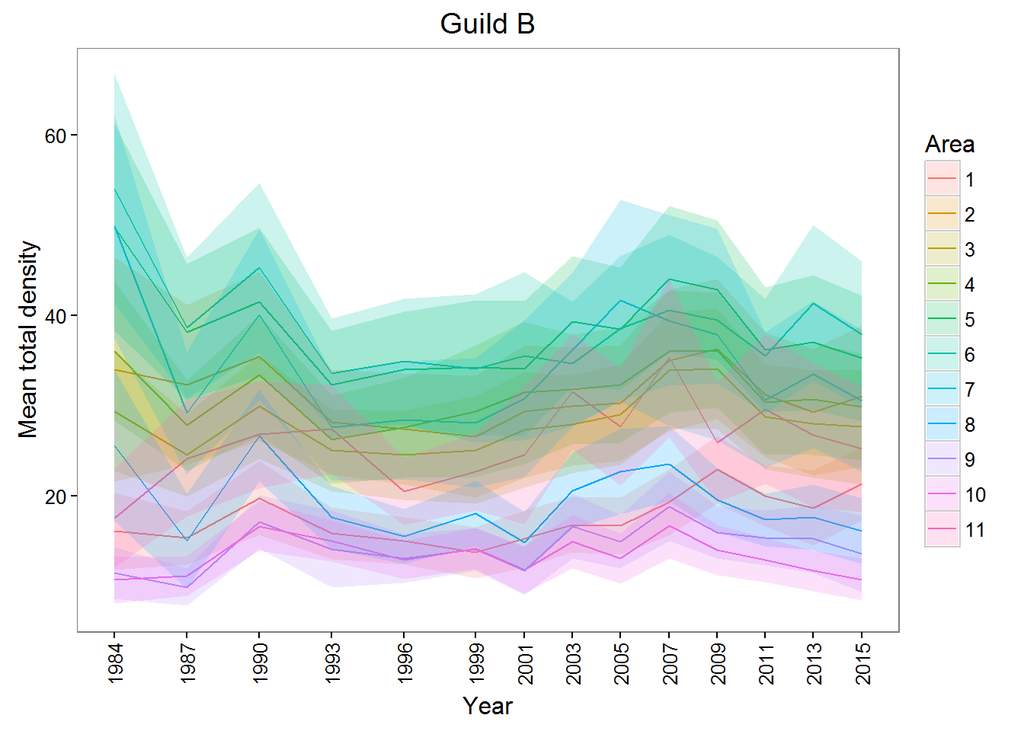

```r
sp <- subset(trawl_species, guild=='B')
sp <- droplevels(sp)
sp.names <- as.list(levels(sp$database.name))

group <- meanCPUE[meanCPUE$Species %in% sp.names,]

vplot(group, title="Guild B")
```

[output not shown]

[output not shown]

[output cut: 25 more lines]

[output not shown]

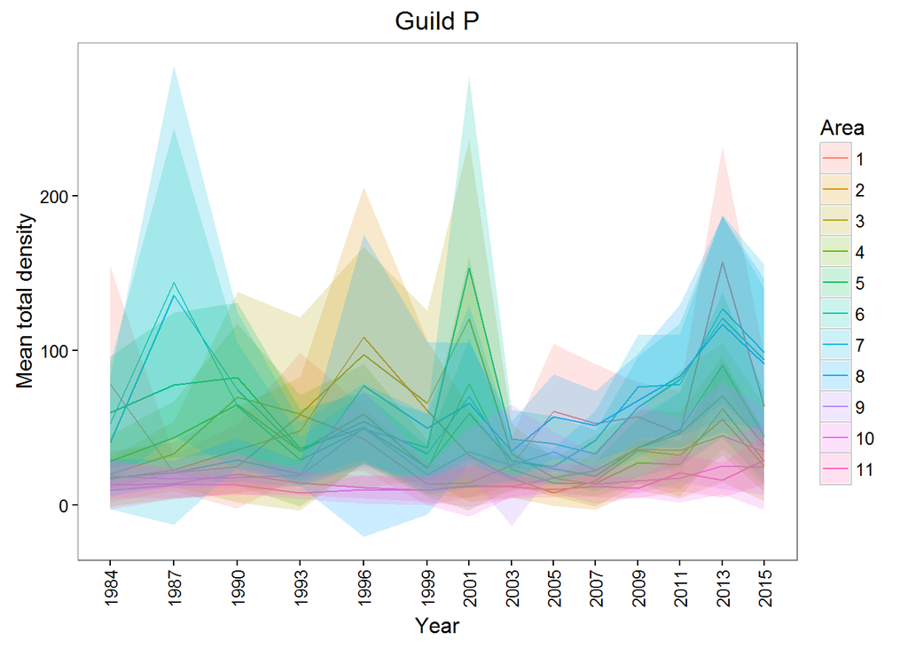

```r
sp <- subset(trawl_species, guild=='P')
sp <- droplevels(sp)
sp.names <- as.list(levels(sp$database.name))

group <- meanCPUE[meanCPUE$Species %in% sp.names,]

vplot(group, title="Guild P")
```

[output not shown]

[output not shown]

[output cut: 25 more lines]

[output not shown]

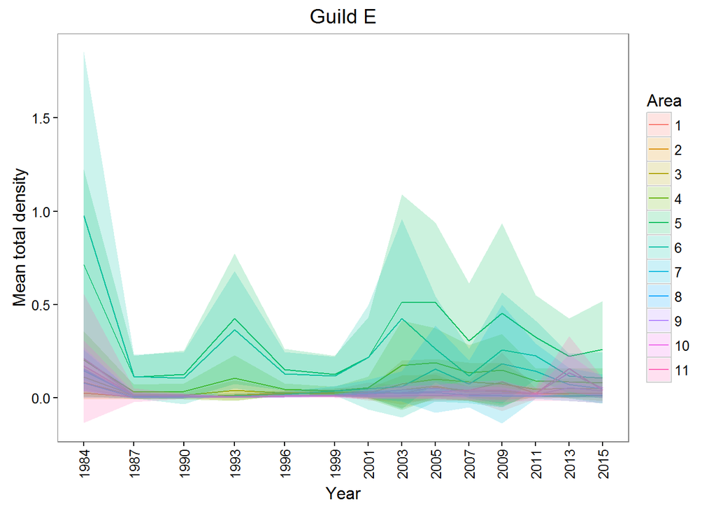

```r
sp <- subset(trawl_species, guild=='E')
sp <- droplevels(sp)
sp.names <- as.list(levels(sp$database.name))

group <- meanCPUE[meanCPUE$Species %in% sp.names,]

vplot(group, title="Guild E")
```

Examine by diet

[output not shown]

[output not shown]

[output cut: 25 more lines]

[output not shown]

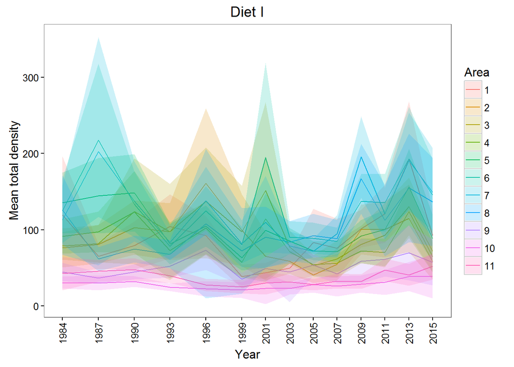

```r
sp <- subset(trawl_species, diet1=='I' | diet2=="I")
sp <- droplevels(sp)
sp.names <- as.list(levels(sp$database.name))

group <- meanCPUE[meanCPUE$Species %in% sp.names,]

vplot(group, title="Diet I")
```

Plot of the sum and variance of mean total density by year and area

[output not shown]

[output not shown]

[output cut: 25 more lines]

[output not shown]

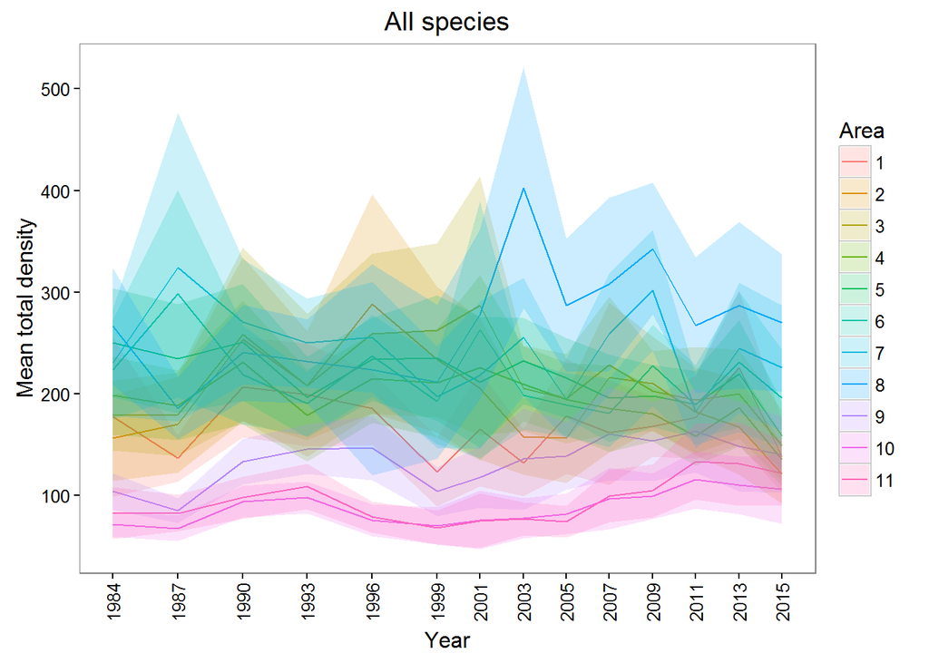

```r
vplot(meanCPUE, title="All species")
```

Area 8 jumps out as higher than the other areas

Examine all species minus Walleye Pollock, Arrowtooth Flounder and Pacific Halibut

[output not shown]

[output not shown]

[output cut: 25 more lines]

[output not shown]

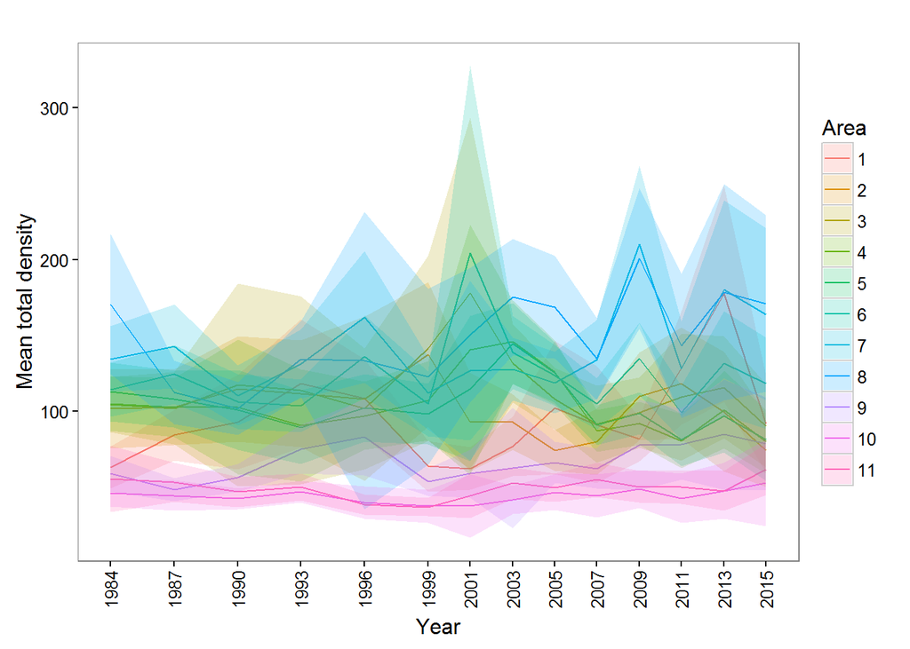

```r
#subset by area
smean <- subset(meanCPUE, Species!="Gadus.chalcogrammus" & Species!="Atheresthes.stomias"& Species!="Hippoglossoides.stenolepis")
smean <- droplevels(smean)

vplot(smean)
```

[output not shown]

[output not shown]

[output cut: 25 more lines]

[output not shown]

[figure not shown]

Cod and Spiny Dogfish

[output not shown]

[output not shown]

[output cut: 25 more lines]

[output not shown]

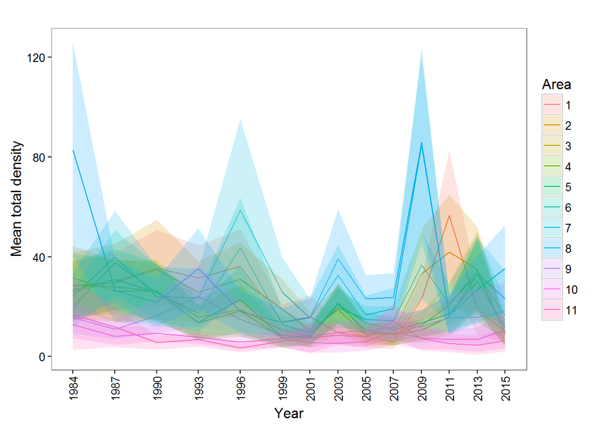

Capelin, Herring, and Eulachon

[output not shown]

[output not shown]

[output cut: 25 more lines]

[output not shown]

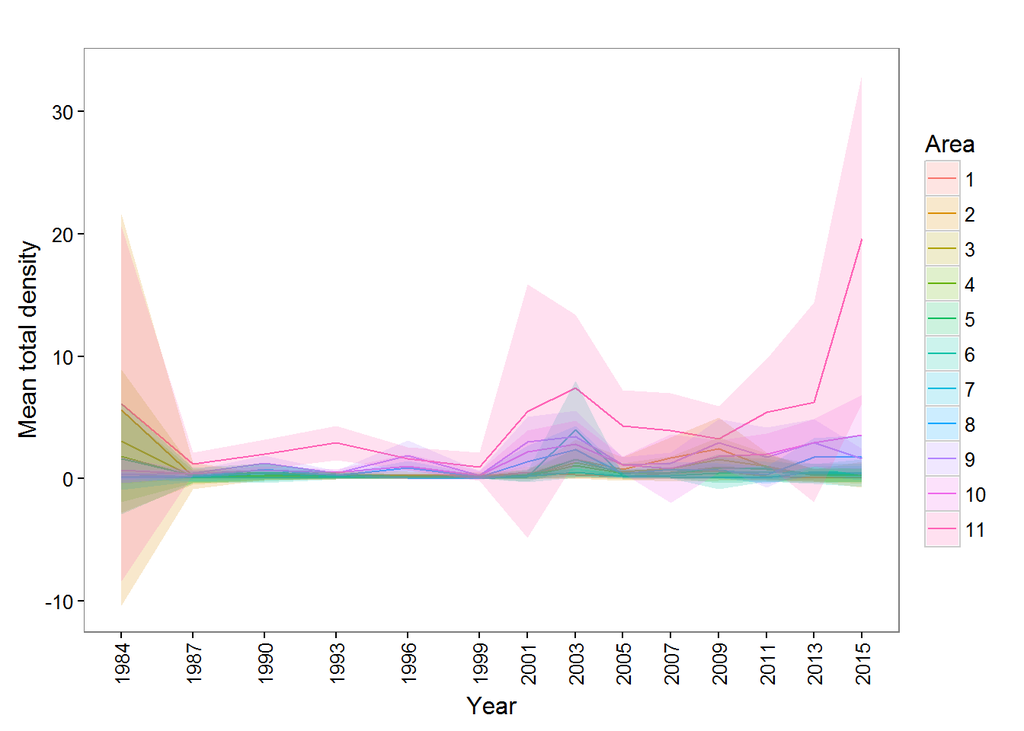

Rock Sole, Yellowfin Sole, Bigmouth Sculpin, Ling Cod

[output not shown]

[output not shown]

[output cut: 25 more lines]

[output not shown]

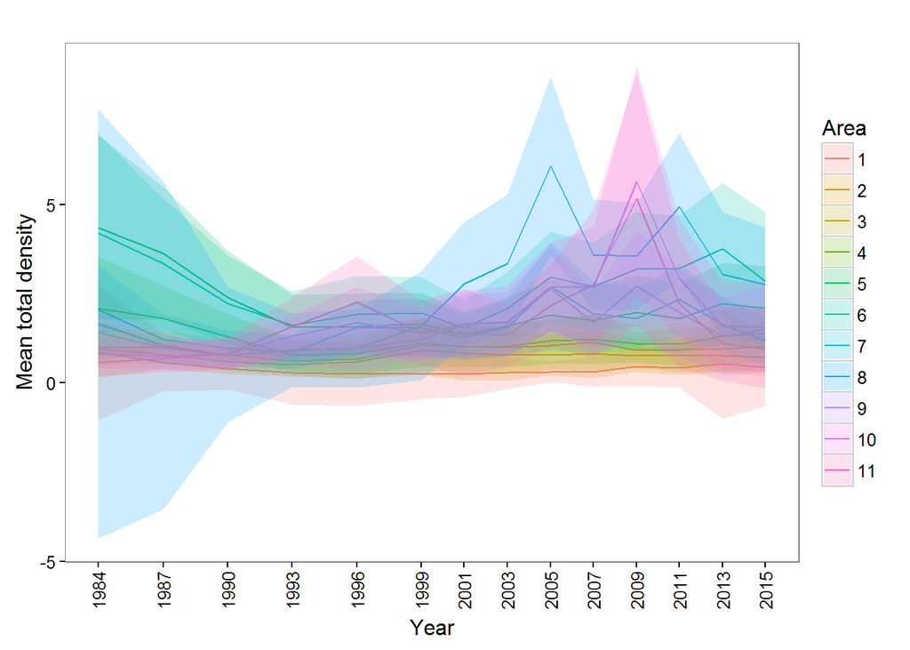

Bairdi Crab

[output not shown]

[output not shown]

[output cut: 25 more lines]

[output not shown]

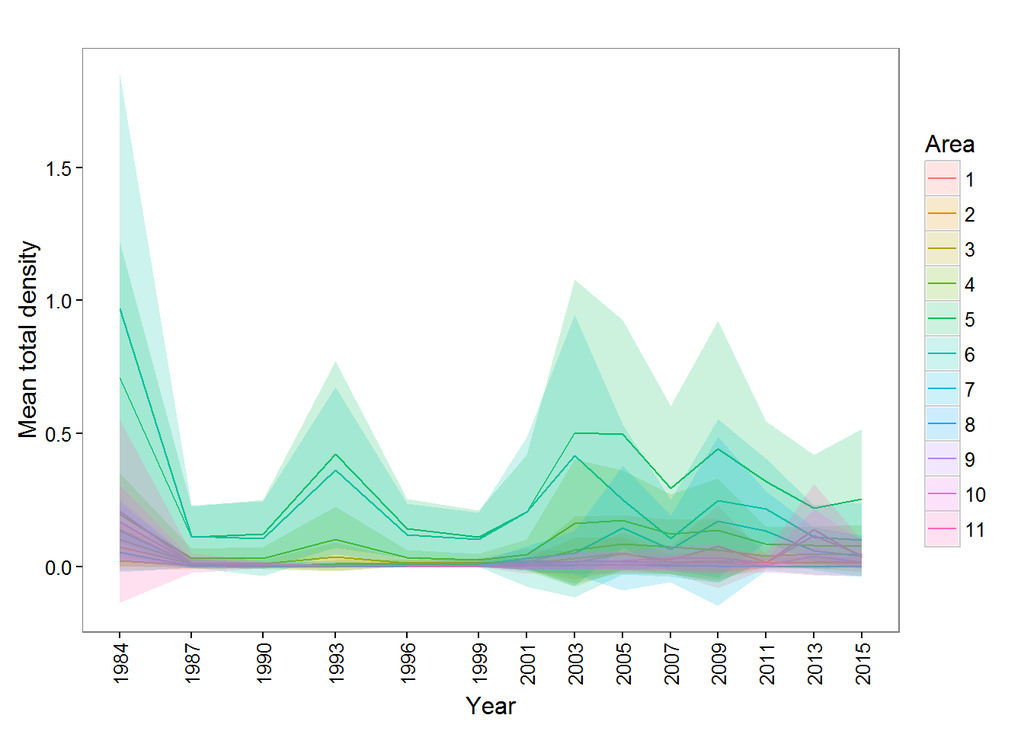